# 2018-11-17-Visualisation-Seaborn

```python
import seaborn as sns
%matplotlib inline
```

```python
import matplotlib.pyplot as plt
```

```python
tips = sns.load_dataset('tips')
```

```python
tips.head()
```

|  | total_bill | tip | sex | smoker | day | time | size |
| --- | --- | --- | --- | --- | --- | --- | --- |
| 0 | 16.99 | 1.01 | Female | No | Sun | Dinner | 2 |
| 1 | 10.34 | 1.66 | Male | No | Sun | Dinner | 3 |
| 2 | 21.01 | 3.50 | Male | No | Sun | Dinner | 3 |
| 3 | 23.68 | 3.31 | Male | No | Sun | Dinner | 2 |
| 4 | 24.59 | 3.61 | Female | No | Sun | Dinner | 4 |

## Distribution plots

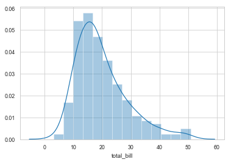

```python
sns.distplot(tips['total_bill'])
```

This line is called as a KDE = kernel density estimation

#### we can remove it as an additional argument in the function

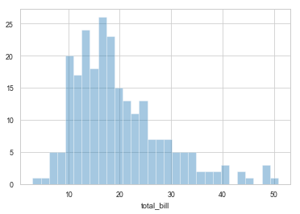

```python
sns.distplot(tips['total_bill'], kde = False, bins = 30)
```

### Jointplot

Match two different distribution plots

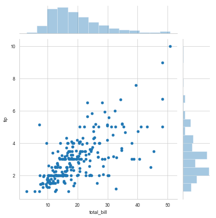

```python
sns.jointplot(data = tips, x = 'total_bill', y = 'tip')
```

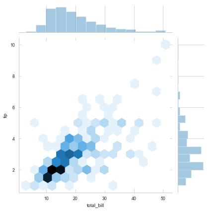

```python
sns.jointplot(data = tips, x = 'total_bill', y = 'tip', kind = 'hex')
plt.show()
```

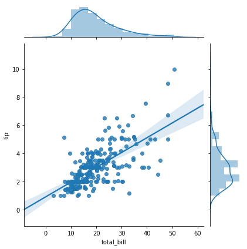

```python
sns.jointplot(data = tips, x = 'total_bill', y = 'tip', kind = 'reg')
```

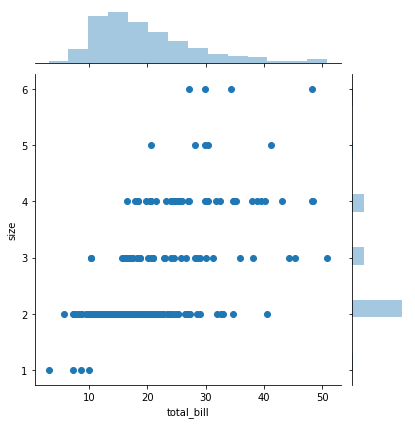

```python
sns.jointplot(tips['total_bill'], tips['size'])
```

```python
import warnings
warnings.filterwarnings('ignore')
```

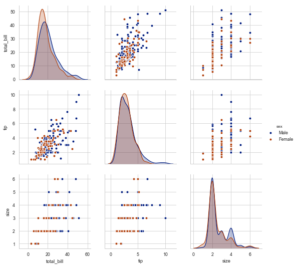

```python
sns.pairplot(tips, hue = 'sex', palette = 'dark')
```

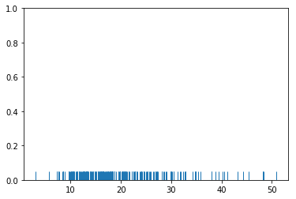

```python
sns.rugplot(tips['total_bill'])
```

The difference between a histogram and this rugplot is that histogram has bins and count of many dashes are in that bin and shows it as a number. The KDE is built on the rugplot.

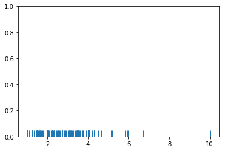

```python
sns.rugplot(tips['tip'])
```

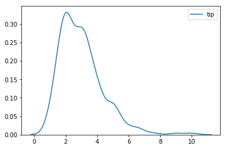

```python
sns.kdeplot(tips['tip'])
```

## Categoricl Plots

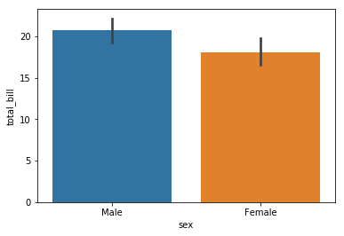

```python
sns.barplot(x = 'sex', y = 'total_bill', data = tips)
```

```python
import numpy as np
```

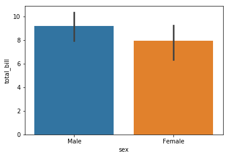

```python
sns.barplot(x = 'sex', y = 'total_bill', data = tips, estimator = np.std)
```

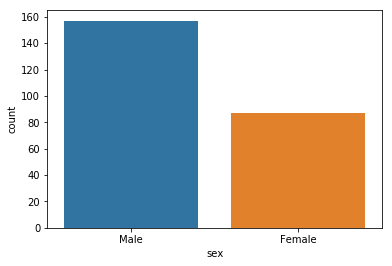

```python
sns.countplot(x= 'sex', data = tips)
```

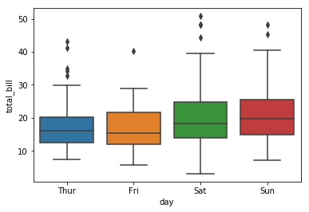

```python
sns.boxplot(x = 'day', y = 'total_bill', data = tips)
```

The dots are outliers

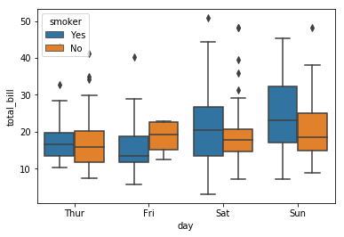

```python
sns.boxplot(x = 'day', y = 'total_bill', data = tips, hue = 'smoker')
```

Violin plot plays a similar role as boxplot.

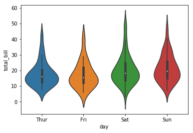

```python
sns.violinplot(x = 'day', y = 'total_bill', data = tips)
```

The violinplot lets us plot all the elements contained in the dataset, unlike boxplot, it is showing the kernel density of the underlying distribution

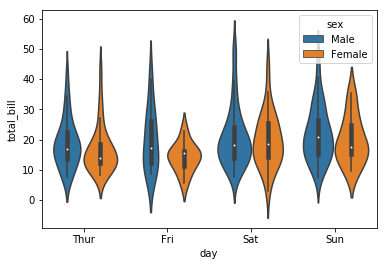

```python
sns.violinplot(x = 'day', y = 'total_bill', data = tips, hue = 'sex')
```

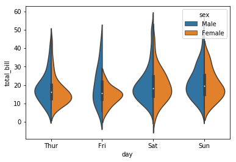

```python
sns.violinplot(x = 'day', y = 'total_bill', data = tips, hue = 'sex', split = True)
```

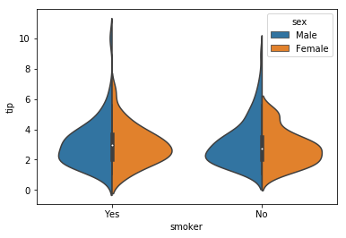

```python
sns.violinplot(x = 'smoker', y = 'tip', hue = 'sex', split = True, data = tips)
```

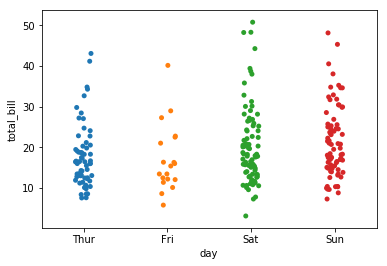

```python
sns.stripplot(x = 'day', y = 'total_bill', data = tips)
```

The jitter argument adds a random noise

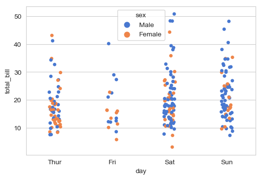

```python
fig = plt.figure(dpi = 100)
sns.set_style("whitegrid")
sns.stripplot(x = 'day', y = 'total_bill', data = tips, palette = 'muted', hue = 'sex')
```

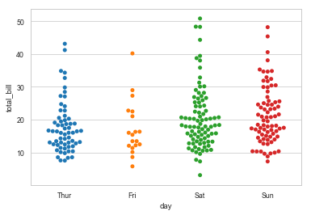

```python
sns.swarmplot(x= 'day', y = 'total_bill', data = tips)
```

It is recommanded to use swarmplot for little data sets

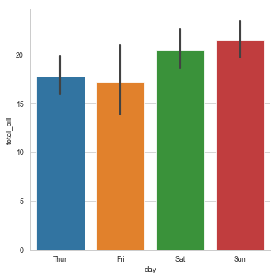

```python
sns.factorplot(x= 'day', y = 'total_bill', data = tips, kind = 'bar')
```

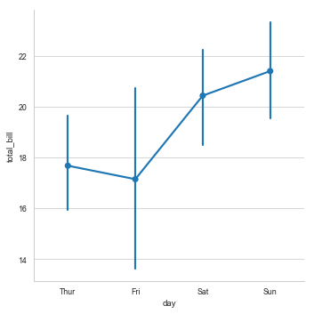

```python
sns.factorplot(x= 'day', y = 'total_bill', data = tips, kind = 'point')
```

# Matrix Plots

```python
flights = sns.load_dataset('flights')
```

```python
flights.head()
```

|  | year | month | passengers |
| --- | --- | --- | --- |
| 0 | 1949 | January | 112 |
| 1 | 1949 | February | 118 |
| 2 | 1949 | March | 132 |
| 3 | 1949 | April | 129 |
| 4 | 1949 | May | 121 |

```python
tips.corr()
```

|  | total_bill | tip | size |
| --- | --- | --- | --- |
| total_bill | 1.000000 | 0.675734 | 0.598315 |
| tip | 0.675734 | 1.000000 | 0.489299 |
| size | 0.598315 | 0.489299 | 1.000000 |

```python
tc = tips.corr()
```

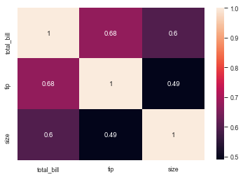

```python
sns.heatmap(tc, annot = True)
```

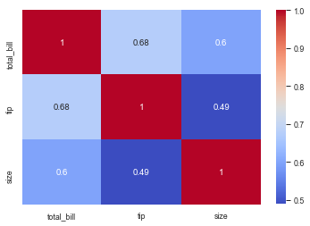

```python
sns.heatmap(tc, annot = True, cmap = 'coolwarm')
```

If we want to plot a heatmap, our data has to be in a matrix form, meaning the rows and colums are variables

```python
flights.head()
```

|  | year | month | passengers |
| --- | --- | --- | --- |
| 0 | 1949 | January | 112 |
| 1 | 1949 | February | 118 |
| 2 | 1949 | March | 132 |
| 3 | 1949 | April | 129 |
| 4 | 1949 | May | 121 |

```python
flights.info()
```

```
<class 'pandas.core.frame.DataFrame'>
RangeIndex: 144 entries, 0 to 143
Data columns (total 3 columns):
year          144 non-null int64
month         144 non-null category
passengers    144 non-null int64
dtypes: category(1), int64(2)
memory usage: 2.9 KB
```

We can tranform this data in a matrix-like form with pivot table

```python
flights.pivot_table(index = 'month', columns = 'year', values = 'passengers')
```

| year month | 1949 | 1950 | 1951 | 1952 | 1953 | 1954 | 1955 | 1956 | 1957 | 1958 | 1959 | 1960 |
| --- | --- | --- | --- | --- | --- | --- | --- | --- | --- | --- | --- | --- |
| January | 112 | 115 | 145 | 171 | 196 | 204 | 242 | 284 | 315 | 340 | 360 | 417 |
| February | 118 | 126 | 150 | 180 | 196 | 188 | 233 | 277 | 301 | 318 | 342 | 391 |
| March | 132 | 141 | 178 | 193 | 236 | 235 | 267 | 317 | 356 | 362 | 406 | 419 |
| April | 129 | 135 | 163 | 181 | 235 | 227 | 269 | 313 | 348 | 348 | 396 | 461 |
| May | 121 | 125 | 172 | 183 | 229 | 234 | 270 | 318 | 355 | 363 | 420 | 472 |
| June | 135 | 149 | 178 | 218 | 243 | 264 | 315 | 374 | 422 | 435 | 472 | 535 |
| July | 148 | 170 | 199 | 230 | 264 | 302 | 364 | 413 | 465 | 491 | 548 | 622 |
| August | 148 | 170 | 199 | 242 | 272 | 293 | 347 | 405 | 467 | 505 | 559 | 606 |
| September | 136 | 158 | 184 | 209 | 237 | 259 | 312 | 355 | 404 | 404 | 463 | 508 |
| October | 119 | 133 | 162 | 191 | 211 | 229 | 274 | 306 | 347 | 359 | 407 | 461 |
| November | 104 | 114 | 146 | 172 | 180 | 203 | 237 | 271 | 305 | 310 | 362 | 390 |
| December | 118 | 140 | 166 | 194 | 201 | 229 | 278 | 306 | 336 | 337 | 405 | 432 |

```python
fp = flights.pivot_table(index = 'month', columns = 'year', values = 'passengers')
```

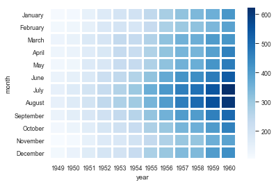

```python
sns.heatmap(fp, cmap = 'Blues', lw = 2)
```

```python
## Cluster map
```

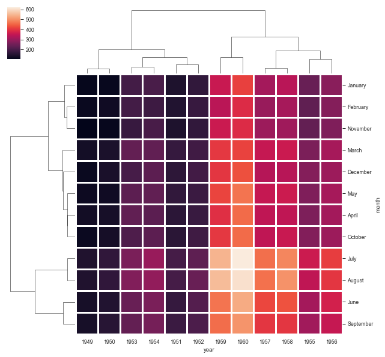

```python
sns.clustermap(fp, lw = 2)
```

The data is clustered in hierarchy. The years and month are not in proper order

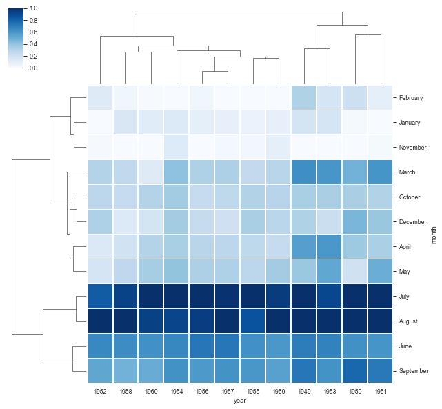

```python
# We can add different arguments to this clustermap
sns.clustermap(fp, lw = 1, cmap = 'Blues', standard_scale= 1)
```